# Predict Liver Disease

Harcharan Kabbay

12/12/2020

## Introduction

This report analyzes a data set of health records and try to find patterns that can be used to predict liver disease in a person. The data set used for analysis is available at [Kaggle Indian-Liver-Patients](https://www.kaggle.com/uciml/indian-liver-patient-records). The goal is to find an algorithm/model that can be used to predict from the given set of data if the person has a liver disease or not. The approach is to find any correlations between Dataset column (that contains the information on disease/no disease) and other columns in data set. At a high level, following steps are performed to finalize a prediction model.  
- Data Analysis: Inspect the data and perform any cleanup required.  
- Data Visualization - Feature selection - Identify patterns and correlations - Predict whether a patient has liver disease or not.

## Data Analysis

The data set contains 416 records for persons with liver disease and 167 for those without a liver disease. Data set contains records for 441 males and 142 females, which age range from 4 years to 90 years.

Here are the data set columns and related information: -  
Columns:  
* Age: Age of the patient  
* Gender: Gender of the patient  
* Total_Bilirubin: Bilirubin is an orange-yellow pigment that occurs normally when part of your red blood cells break down.  
* Direct_Bilirubin: This is the bilirubin once it reaches the liver and undergoes a chemical change.  
* Alkaline_Phosphotase: Alkaline phosphatase is an enzyme you have in your liver, bile ducts, and bone.  
* Alamine_Aminotransferase: Your body uses (Alamine Aminotransferase) ALT to break down food into energy.  
* Aspartate_Aminotransferase: (Aspartate Aminotransferase) AST is an enzyme your liver makes  
* Total_Protiens: The total protein test measures the total amount of two classes of proteins i.e. albumin and globulin.  
* Albumin: Albumin’s a building block that helps your body heal.  
* Albumin_and_Globulin_Ratio: Ratio of protiens albumin and globulin  
* Dataset: Split the data into two sets (patient with liver disease, or no disease)

*Note*: Information on columns have been gathered from [WebMD](https://www.webmd.com)

```
## tibble [583 × 11] (S3: spec_tbl_df/tbl_df/tbl/data.frame)
##  $ Age                       : num [1:583] 65 62 62 58 72 46 26 29 17 55 ...
##  $ Gender                    : chr [1:583] "Female" "Male" "Male" "Male" ...
##  $ Total_Bilirubin           : num [1:583] 0.7 10.9 7.3 1 3.9 1.8 0.9 0.9 0.9 0.7 ...
##  $ Direct_Bilirubin          : num [1:583] 0.1 5.5 4.1 0.4 2 0.7 0.2 0.3 0.3 0.2 ...
##  $ Alkaline_Phosphotase      : num [1:583] 187 699 490 182 195 208 154 202 202 290 ...
##  $ Alamine_Aminotransferase  : num [1:583] 16 64 60 14 27 19 16 14 22 53 ...
##  $ Aspartate_Aminotransferase: num [1:583] 18 100 68 20 59 14 12 11 19 58 ...
##  $ Total_Protiens            : num [1:583] 6.8 7.5 7 6.8 7.3 7.6 7 6.7 7.4 6.8 ...
##  $ Albumin                   : num [1:583] 3.3 3.2 3.3 3.4 2.4 4.4 3.5 3.6 4.1 3.4 ...
##  $ Albumin_and_Globulin_Ratio: num [1:583] 0.9 0.74 0.89 1 0.4 1.3 1 1.1 1.2 1 ...
##  $ Dataset                   : num [1:583] 1 1 1 1 1 1 1 1 2 1 ...
##  - attr(*, "spec")=
##   .. cols(
##   ..   Age = col_double(),
##   ..   Gender = col_character(),
##   ..   Total_Bilirubin = col_double(),
##   ..   Direct_Bilirubin = col_double(),
##   ..   Alkaline_Phosphotase = col_double(),
##   ..   Alamine_Aminotransferase = col_double(),
##   ..   Aspartate_Aminotransferase = col_double(),
##   ..   Total_Protiens = col_double(),
##   ..   Albumin = col_double(),
##   ..   Albumin_and_Globulin_Ratio = col_double(),
##   ..   Dataset = col_double()
##   .. )
```

*Data Cleaning*: Four records have missing value for column Albumin_and_Globulin_Ratio, we’ll remove these records from the data set so that our results remain meaningful.

```r
## Identify missing data
colSums(sapply(df, is.na))
```

```
##                        Age                     Gender
##                          0                          0
##            Total_Bilirubin           Direct_Bilirubin
##                          0                          0
##       Alkaline_Phosphotase   Alamine_Aminotransferase
##                          0                          0
## Aspartate_Aminotransferase             Total_Protiens
##                          0                          0
##                    Albumin Albumin_and_Globulin_Ratio
##                          0                          4
##                    Dataset
##                          0
```

```r
## Remove 4 NA rows
df <- na.omit(df)
```

Number of records by liver disease

```r
table(df$Dataset)
```

```
##
##   1   2
## 414 165
```

For simplicity, we will subtract “1” from column Dataset to make the values 0 (for liver disease) and 1 (for no liver disease), followed by conversion to a factor vector.

```r
df <- df %>% mutate(Dataset = Dataset-1)
df <- rename(df, Disease = Dataset)
table(df$Disease)
```

```
##
##   0   1
## 414 165
```

```r
df <- df %>% mutate(Disease = as.factor(Disease))
```

*Data Visualization*  
Now we can start visualizing the data. These are the graphs for values in each column just to understand the range and spread of in each column.

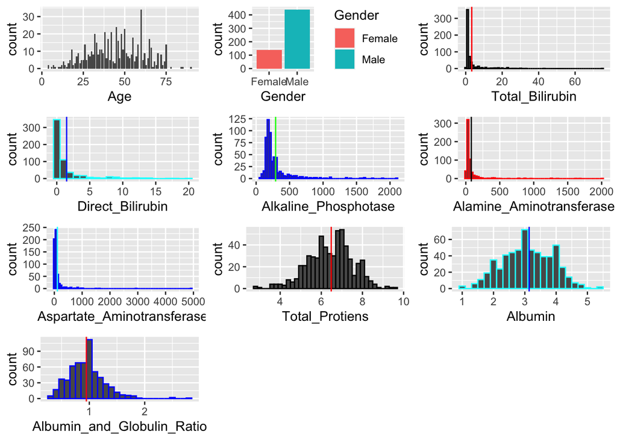

Data visualization provides us some insight into what data looks like, however, we still do not know how this data is related. We will create a correlation matrix to find the strength and direction of the correlation. This can be achieved by using `cor` function to find the correlation and then plot the graph using `corrplot`.

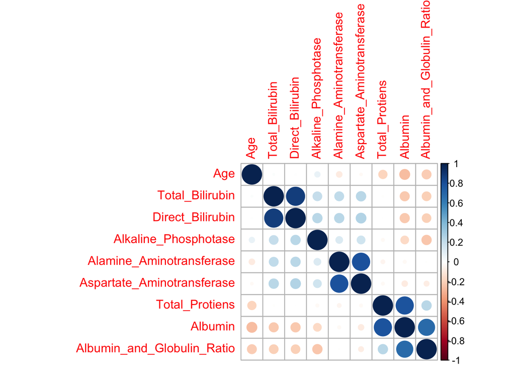

Correlation graph explains the relationship between different fields, and also shows some high correlation pairs. We identified that columns “Albumin”, “Direct_Bilirubin” and “Aspartate_Aminotransferase” are in high correlation pairs and were hence removed from further analysis.

```
## [1] "Albumin"                    "Direct_Bilirubin"
## [3] "Aspartate_Aminotransferase"
```

At this stage, we have a cleaned data set with the final number of features.

## Methods

In order to test different prediction algorithms/models, we split the data set into train and test sets with 70% to 30% ratio respectively.

```
##
##   0   1
## 289 115
```

```
##
##   0   1
## 125  50
```

### Random forest Model

|  | mtry |
| --- | --- |
| 1 | 1 |

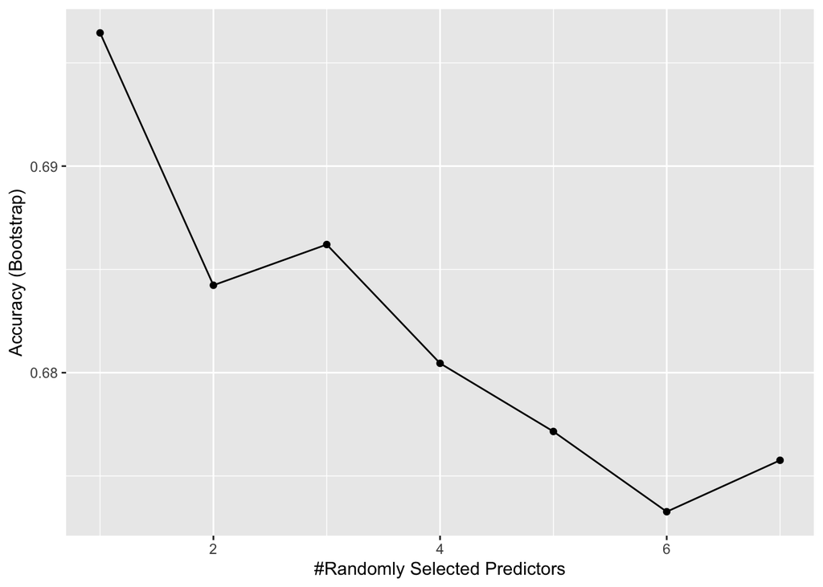

```
## [1] 0.72
```

RandomForest also gives the list of variables sorted by their importance. We can understand the data in a better way by looking at it e.g. Alamine_Aminotransferase is the most important feature in determining the liver-disease in a person while gender makes no difference.

```
## rf variable importance
##
##                            Overall
## Alamine_Aminotransferase    100.00
## Total_Bilirubin              91.00
## Alkaline_Phosphotase         90.30
## Age                          70.52
## Total_Protiens               60.35
## Albumin_and_Globulin_Ratio   56.85
## GenderMale                    0.00
```

### GLM

Generalized Linear Model or GLM is chosen as a second method to create model on train set and perform the prediction on test set. First run of the `glm` was performed for all the available features using simple formula `train(Disease ~ . , method = "glm", data = train_set)`. Accuracy of glm comes out to be **70.3%**. Next, we removed Gender and Albumin_and_Globulin_Ratio from the features and re-ran the glm model. Predictions performed by updated model have improved accuracy of **72%**.

### KNN

Final method for the analysis is Knn. We ran the model using a sequence of values for k so as to find the most optimized **k** which comes out to be 33.

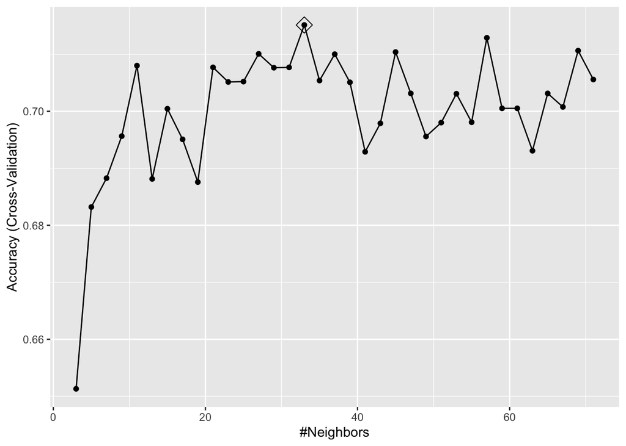

We can also plot the accuracy graph for the sequence of values of **k** used in our knn model.

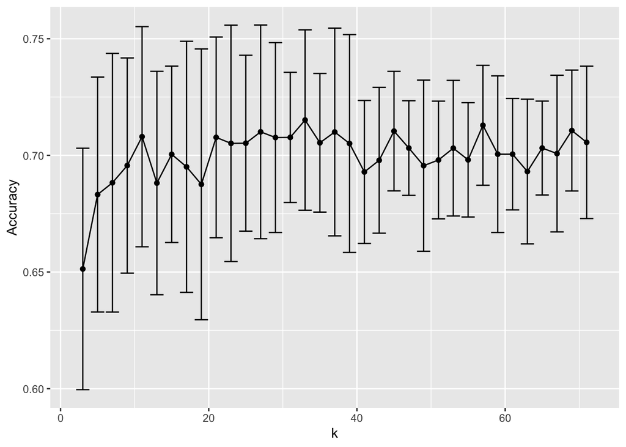

```
##  Accuracy
## 0.6971429
```

We found an accuracy of 69.7% on test set using the Knn method.

## Results

So far, we trained models Random forest, GLM and Knn on train set, followed by performing the predictions on test set. Here are the final results of accuracy observed for each data set.

[output not shown]

## Conclusion

The report covers a high level methodology to understand and analyze the patient data to find correlations and build models. Correlations are often used as a first step before exploring models, which helps us reduce the number of features. We also observed that reducing the most un-reliable features helps improve the accuracy score (e.g. in GLB where the score improved to **72%**.  
Though, this is a very tiny data set of 579 records to build and predict models, still the method can be leveraged to build a good prediction system to aid the medical specialists to predict disease in patients.